en_GBR_dailyt_int

**Du** 01 janvier 2014 **au** 30 juin 2015

| Le média : | Le Flux RSS : |
| --- | --- |
| NOM : **Daily telegraph** | URL du site : **http://www.telegraph.co.uk/** |
| TYPE : **quotidien** | CATEGORIE : **International** |
| PAYS : **GBR** | LANGUE : **anglais** |

**Statistiques sur les items “bruts” et dédoublonnés :**

[output not shown]

**Items bruts** = tous les items stockés de la base de données durant la pèriode choisie.

**Items dédoublonnés** = Items bruts - Doublons.

**Doublons** = **Item RSS dont le titre+description est stricement identique à un autre, sur toute la période choisie**.

**Item Unique** = Items pour lesquels au moins un doublon a été détecté et supprimé.

**Ruptures journalières** = Jours durant lesquels aucun item n’a été collecté. Elles sont soit “natuelles” soit “informatiques” (disfonctionnement de l’outil de collecte).

Nombre d’items “bruts” et dédoublonnés par jour

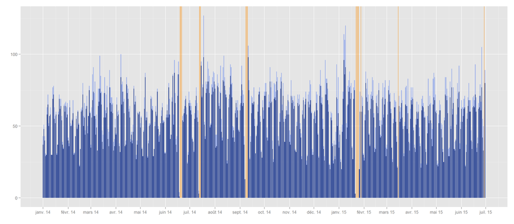

Nombre de doublons détectés et supprimés

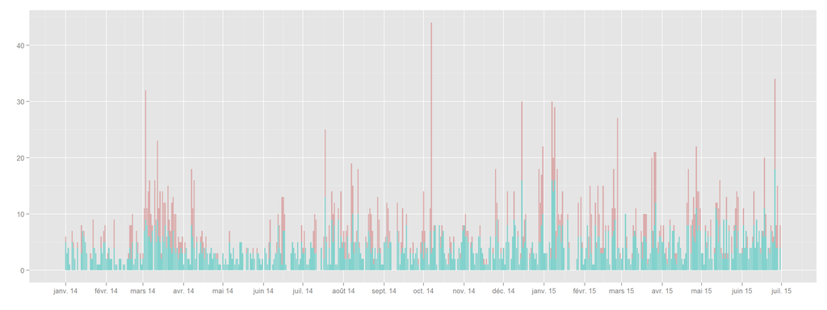

Moyenne mobile (7 jours) du nombre d’items “bruts” et dédoublonnés

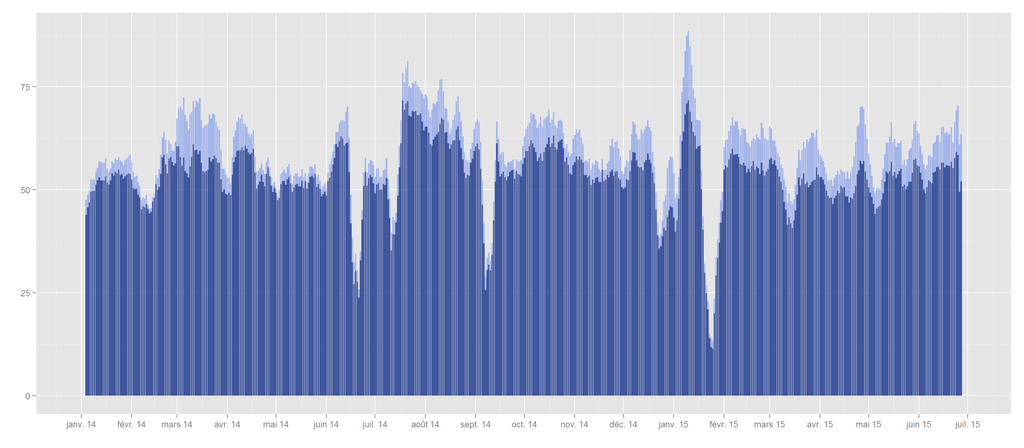

Cycle hebdomadaire des items “bruts”

Écart au nombre moyen d’items collectés par jour. Cycle calculé sur l’ensemble de la période, ruptures incluses

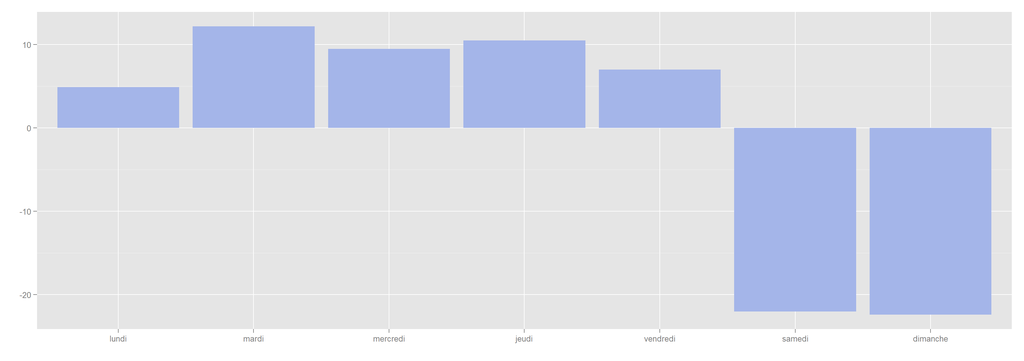

Cycle hebdomadaire des items dédoublonnés

Écart au nombre moyen d’items collectés par jour. Cycle calculé sur l’ensemble de la période, ruptures incluses

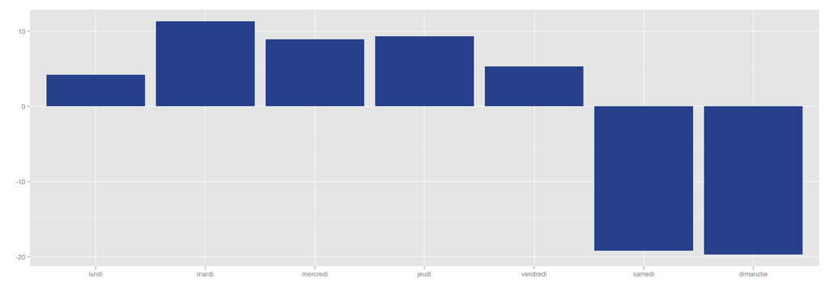

**Contenu des items dédoublonnés :**

| Contenu du titre : | Contenu de la description : |
| --- | --- |
| Nb de caractères min : **9** | Nb de caractères min : **0** |
| Nb de caractères max : **142** | Nb de caractères max : **403** |
| Nb de caractères moyen : **61** | Nb de caractères moyen : **131** |
| Nb de caractères médian : **60** | Nb de caractères médian : **130** |
| Ecart-type : **17** | Ecart-type : **39** |
| Nb Items sans titre : **0** | Nb Items sans description : **24** |

Nombre de caractères dans le titre des items, par jour

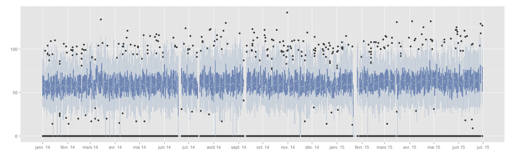

Nombre de caractères dans la descritpion des items, par jour

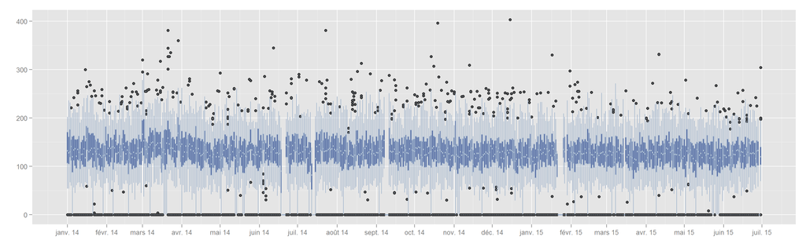

**Résultat du taggage géographiques (dico PaysV4 ) des items dédoublonnés :**

| Statistiques sur le Geotaggage |  |
| --- | --- |
| Nb de GeoTAG Total : **25267** | Nb de GeoTAG Unique : **173** |
| Part d’items taggés : **69.7 %** | Moyenne de répétition des TAGs detectés : **146.1** |
| Moyenne du Nb de TAG par item : **0.9** | Mediane de répétition des TAGs detectés : **18** |
| Mediane du Nb de TAG par item : **1** | Ecart-type des répétitions des TAGs detectés : **409.8** |
| Ecart-type du Nb de TAG par item : **0.71** | Minimum de répétitions des TAGs detectés : **1** |
| Nb de TAG minimum par item : **0** | Maximum de répétitions des TAGs detectés : **4107** |
| Nb de TAG maximum par item : **5** |  |
| Moyenne du Nb de TAG par jour : **47.6** | Moyenne du Nb de TAG par semaine : **316** |
| Mediane du Nb de TAG par jour : **1** | Mediane du Nb de TAG par semaine : **318** |
| Ecart-type du Nb de TAG par jour : **16.7** | Ecart-type du Nb de TAG par semaine : **78** |
| Nb de TAG minimum par jour : **0** | Nb de TAG minimum par semaine : **73** |
| Nb de TAG maximum par jour : **128** | Nb de TAG maximum par semaine :**484** |

**Items dédoublonnés** = “items bruts - doublons”.

**Items Geo-taggués**. Il s’agit des items dans lesquels au moins un pays a été détécté automatiquement, en utilisant le ditionnaire " PaysV4 “.

Nombre d’items geo-taggués sur l’ensemble des items dédoublonnés

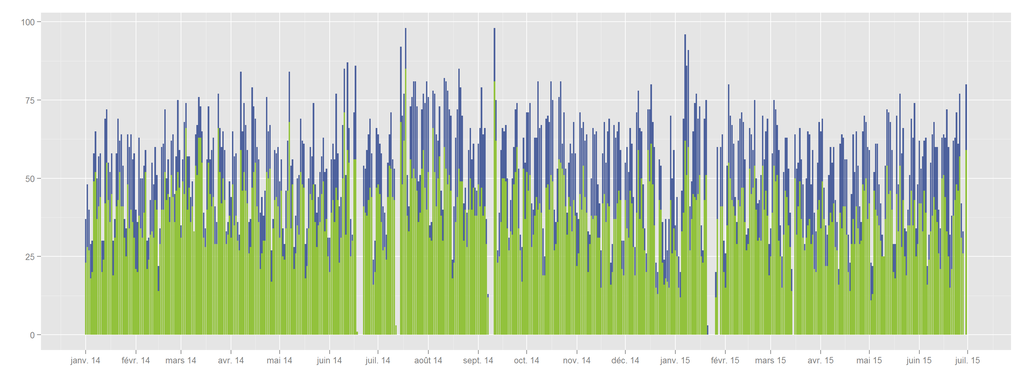

Liste et nombre des TAGs (les 50 plus cités) géographiques détectés

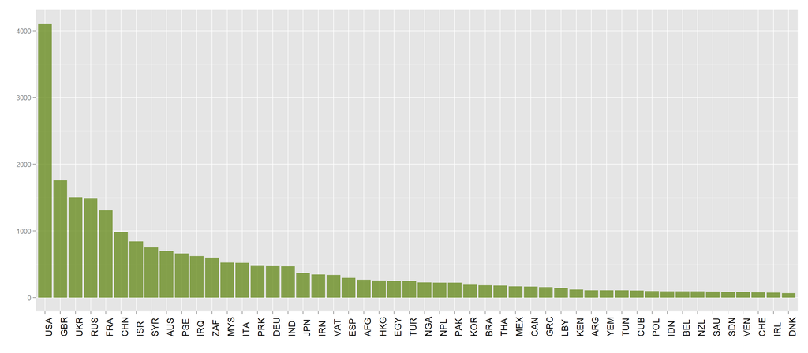

TAGs géographiques détéctés (les 50 plus cités) dans le temps

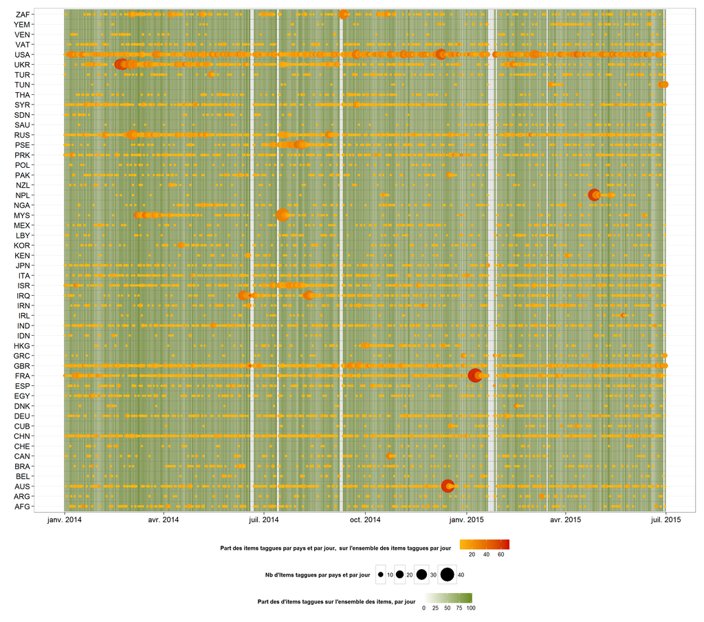

Répartition géographique des TAGs détectés

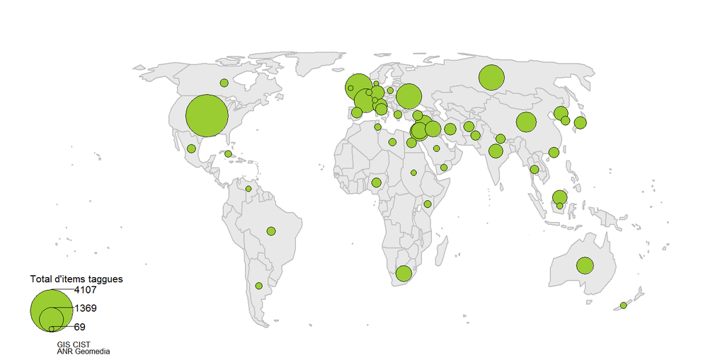

**Cooccurrences des TAGs geographiques (dico PaysV4 ) :**

| Statistiques sur les Cooccurrences des TAGs Geographiques |  |
| --- | --- |
| Total des cooccurrences : **5594** | Nb de cooccurrences Unique : **641** |
| Part des items geo-taggés comportant des cooccurrences : **22.7 %** | Rrépétition moyenne des cooccurrences : **8.7** |
| Nb de cooccurrences moyen : **1.2** | Mediane de répétition des cooccurrences : **2** |
| Nb de cooccurrences médian : **1** | Ecart-type des répétitions des cooccurrences : **35.4** |
| Ecart-type du Nb de cooccurrences : **0.7** | Minimum de répétitions des cooccurrences : **1** |
| Nb de cooccurrences minimum : **1** | Maximum de répétitions des cooccurrences : **664** |
| Nb de cooccurrences maximum : **10** |  |
| Nb de cooccurrences moyen par jour : **10.7** | Moyenne du Nb de cooccurrences par semaine : **70** |
| Nb de cooccurrences médian par jour : **1** | Mediane du Nb de cooccurrences par semaine : **63** |
| Ecart-type du Nb de cooccurrences par jour : **7.4** | Ecart-type du Nb de cooccurrences par semaine : **33** |
| Minimum de cooccurrences par jour : **1** | Nb de cooccurrences minimum par semaine : **6** |
| Maximum de cooccurrences par jour : **55** | Nb de cooccurrences maximum par semaine :**178** |

**Items Geo-taggués**. Il s’agit des items dans lesquels **au moins 1 pays a été détécté** automatiquement, en utilisant le ditionnaire " PaysV4 “.

**Items co-taggués**.Il s’agit des items dans lesquels **au moins 2 pays ont été détéctés** automatiquement, en utilisant le ditionnaire " PaysV4 “.

Nombre d’items Geo-taggés comportant des cooccurrences

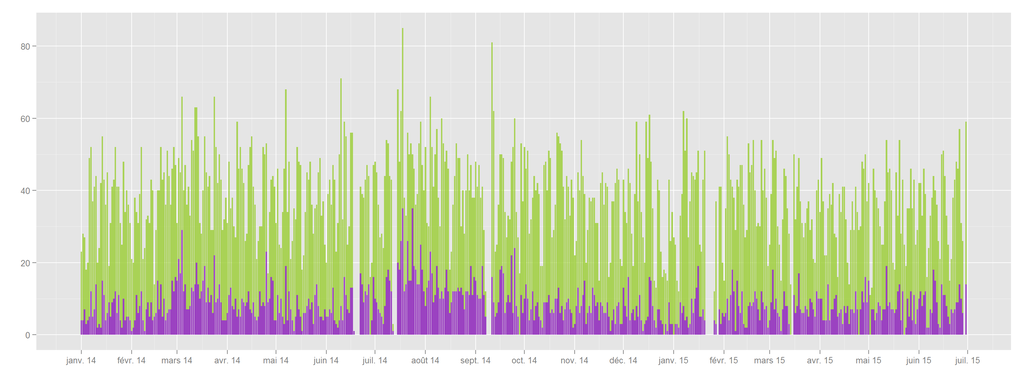

Liste et nombre des cooccurrences de Geo-tags trouvés

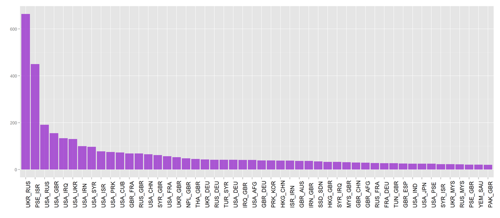

Coocurrence des TAGs géographiques détéctés (les 50 plus cités) dans le temps

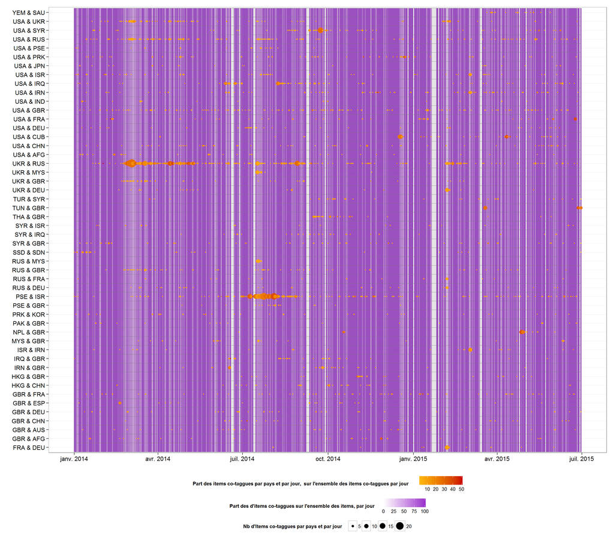

Cocitations de pays - Graphe des flux dominants

**Pays dominants**. Le nombre total de co-citations est supérieur au nombre total de co-citations de chaque pays avec lesquels il est co-cité

**Pays intermediaires**. Le nombre total de co-citations est supérieur ou inférieur au nombre total de co-citations de chaque pays avec lesquels il est co-cité

**Pays Dominés**. Le nombre total de co-citations est inférieur aux nombre total de co-citations de chaque pays avec lesquels il est co-cité

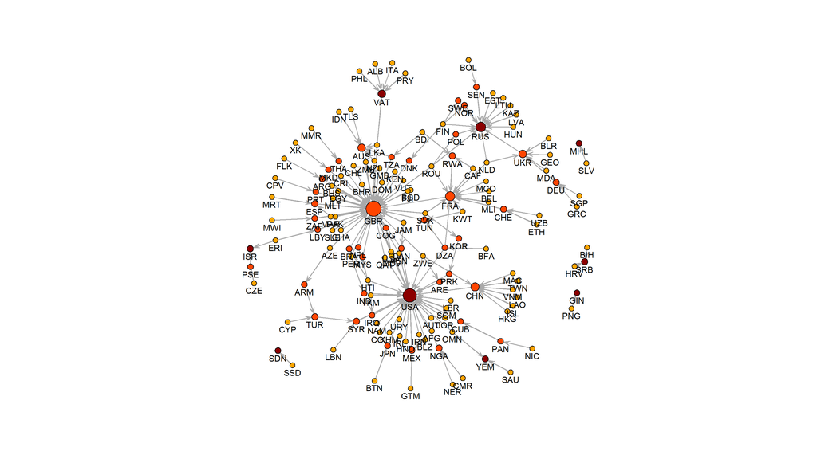

**Résultat du taggage de l’événement “Ebola” dans les items dédoublonnés :**

[output not shown]

**Items dédoublonnés** = “items bruts - doublons”.

**Items taggués par l’événement** . Il s’agit des items dans lesquels au moins un mot du dico " Ebola " a été détécté automatiquement.

Nombre d’items taggués avec le dico “Ebola” sur l’ensemble des items dédoublonnés

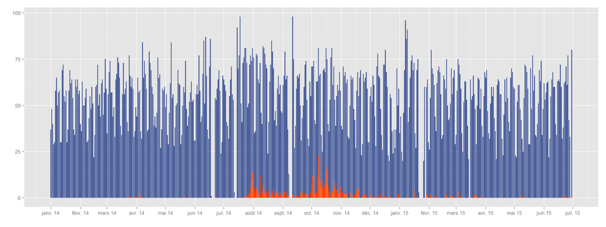

Fréquence cumulée des items taggués avec le dico “Ebola” sur l’ensemble des items dédoublonnés

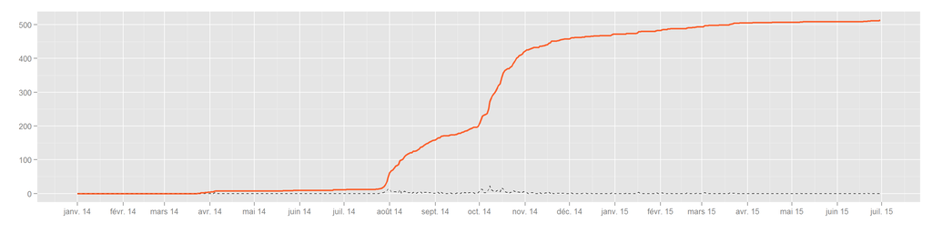

Liste et fréquence des pays co-taggués avec l’événement “Ebola”

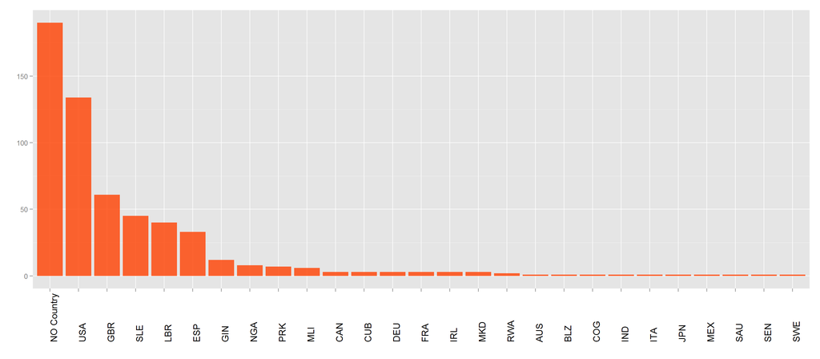

Co-citation de TAG géographique & de l’événement “Ebola” dans les items

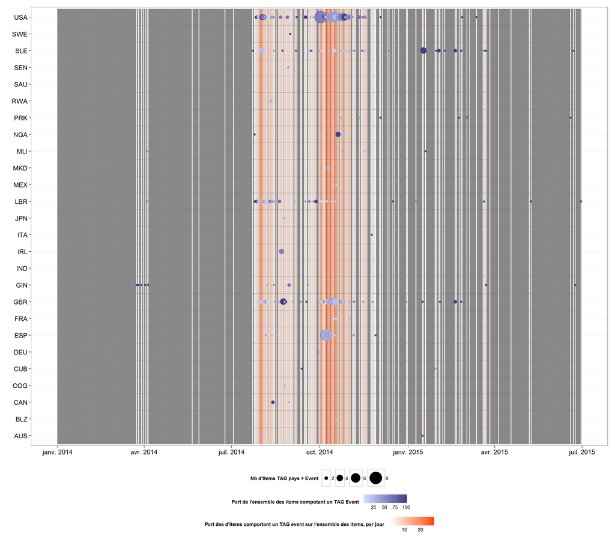

Co-citation de pays & “Ebola”. Graphe des flux (ou noeuds) dominants

**Pays dominants**. Le nombre total de co-citations est supérieur au nombre total de co-citations de chaque pays avec lesquels il est co-cité

**Pays intermediaires**. Le nombre total de co-citations est supérieur ou inférieur au nombre total de co-citations de chaque pays avec lesquels il est co-cité

**Pays Dominés**. Le nombre total de co-citations est inférieur aux nombre total de co-citations de chaque pays avec lesquels il est co-cité

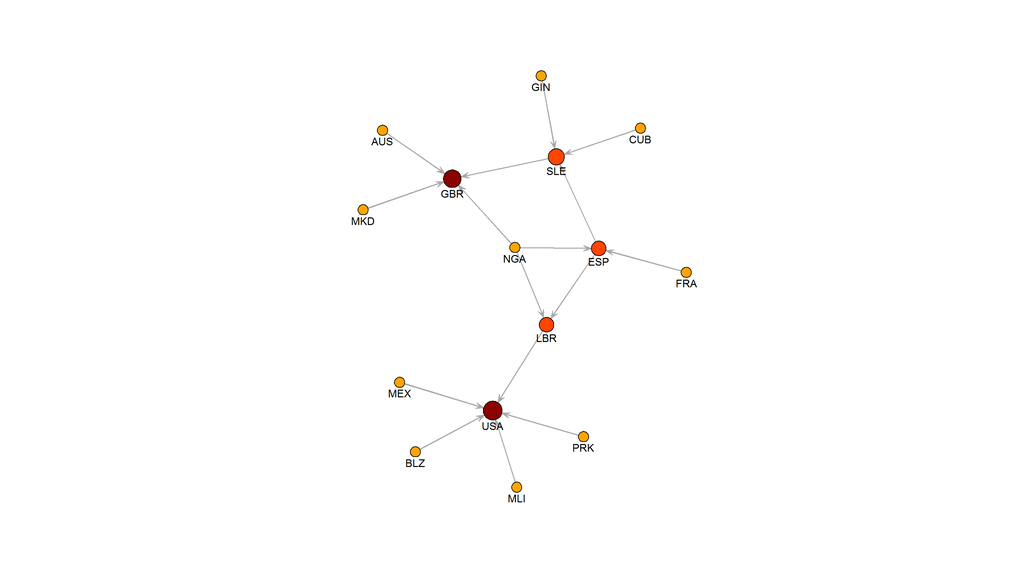